# Medical Education - bibliometric analysis

Caroline S. Armitage

04/28/2023

## Information

This Rmarkdown file contains the code used for the parts of the bibliometric analysis done in R for the publication “Medisinsk utdanningsforskning i Norge de siste 50 årene– en bibliometristudie” (preliminary title) (Kvernenes, Armitage, Almeland & Birkeli). It is available on GitHub: https://github.com/Caroline-A/Medical_education

It uses R package Bibliometrix (among others). Data is imported from files created via export of publication metadata from Web of Science (Clarivate) and PubMed.

## Data import

429 publications were included after screening. 19 of these were not found in PubMed or WoS (Web of Science) - these were found by the CRISTIN or ProQuest search, or by the hand journal search in UNIPED (10 results). These are not included in this analysis as we do not have bibliometric data in the right format.

Data from WoS and PubMed for the 410 publications were downloaded (“plaintext” full record and cited references from WoS, “PubMed export file” from PubMed). This is done by taking the screened results from Rayyan, and searching using the WOS ID/PubMed ID. We end up with 3 files:

- WoS_export_2023-02.txt = The results that are found in Web of Science (257)
- PubMed_export_nonwos_2023-02.txt = The results that are only in PubMed (not found in WoS; 153)
- PubMed_export_all_2023_02.txt = All results that can be found in in PubMed (393)

These are imported, converted to dataframes and merged with bibliometrix. Author keywords from both sets are copied into column OT so that they are retained after merging.

I also create a version of the merged data without citations, since these are missing from the PubMed files.

One of the results had a publication date as 2023 (probably an updating of metadata since the search), so was removed from the analysis.

This leaves 428 publications in total in the study, and 409 in the largest set of bibliometric data.

- Number of items in the WOS data = 257
- Number of items in the PubMed (minus WoS covered works) data = 152
- Number of items in the merged WoS and PubMed data = 409
- Number of items in the only PubMed data set = 392

## Data weaknesses

PubMed is a relatively weak source for affiliation-based data. From 1988-2013, they indexed only the first author’s affiliation information (with it appearing exactly as it does in the publication from 2003-). It was only from 2014 that affiliation data for all authors was included, and from late 2014 that multi-affiliated author affiliations were included. At this point, quality-control of this data ceased (https://www.nlm.nih.gov/bsd/mms/medlineelements.html#ad). Thus:

- Some search results may have been lost before 2014 if the publication was not covered by Web of Science AND a co-author (but not first author) was affiliated in Norway.
- Some search results may be missing if affiliation data is missing (e.g. a number of articles from Tidsskrift for den Norske Legeforening have have no affiliation data in PubMed - for this particular analysis and this journal, this is not an issue as we did a search specifically within this journal without any affiliation limitations).

For institutional affiliations it is best to use Web of Science data.

## Data cleaning

| AU | Freq |
| --- | --- |
| AARAAS I | 2 |
| AARFLOT M | 3 |
| AARLI A | 2 |
| AARSETH O | 3 |
| AASE I | 3 |
| AASE K | 3 |
| AASLAND O | 11 |
| ABDELRAHMAN S | 2 |
| ABELSEN B | 5 |
| AGGARWAL R | 2 |
| AKRE V | 5 |
| ALMELAND S | 4 |
| ANDERSEN G | 3 |
| ANVIK T | 12 |
| ASLAKSEN A | 2 |
| ASSMUS J | 2 |
| AUGESTAD K | 3 |
| AUNE E | 2 |
| BAERHEIM A | 20 |
| BALASUNDARAM I | 2 |
| BANZA L | 3 |
| BELFRAGE A | 2 |
| BENTZEN N | 2 |
| BERG E | 2 |
| BERG H | 2 |
| BIERMANN M | 3 |
| BIJLSMA J | 2 |
| BJERKREIM A | 2 |
| BJORNDAL A | 5 |
| BJUGN R | 4 |

[output cut: 258 more lines]

In the next step I do the same for journal names, it seems like there are several name variants which have to be manually merged/fixed. Note that these are cleaned of commas by bibliomanalysis compared to the original dataframe, so for replacing take the name from the original dataframe.

| SO | Freq |
| --- | --- |
| ACADEMIC PSYCHIATRY | 1 |
| ACADEMIC RADIOLOGY | 2 |
| ACTA OBSTETRICIA ET GYNECOLOGICA SCANDINAVICA | 1 |
| ACTA PAEDIATRICA | 1 |
| ACTA PSYCHIATRICA SCANDINAVICA | 1 |
| ACTA RADIOLOGICA OPEN | 1 |
| ADVANCES IN HEALTH SCIENCES EDUCATION | 4 |
| ADVANCES IN MEDICAL EDUCATION AND PRACTICE | 3 |
| ADVANCES IN MEDICINE | 1 |
| ADVANCES IN SIMULATION (LONDON ENGLAND) | 3 |
| AGE AND AGEING | 1 |
| AGING CLINICAL AND EXPERIMENTAL RESEARCH | 1 |
| ALCOHOL AND ALCOHOLISM | 1 |
| AMERICAN JOURNAL OF SURGERY | 2 |
| ANNALS OF ANATOMY-ANATOMISCHER ANZEIGER | 1 |
| ANNALS OF THE RHEUMATIC DISEASES | 1 |
| ANTHROPOLOGY & MEDICINE | 1 |
| ARTHRITIS RESEARCH & THERAPY | 1 |
| BJS OPEN | 3 |
| BMC HEALTH SERVICES RESEARCH | 1 |
| BMC MEDICAL EDUCATION | 45 |
| BMC MEDICAL ETHICS | 1 |
| BMC MEDICAL IMAGING | 1 |
| BMJ LEADER | 1 |
| BMJ OPEN | 4 |
| BMJ QUALITY & SAFETY | 1 |
| BMJ SIMULATION & TECHNOLOGY ENHANCED LEARNING | 1 |
| BRITISH JOURNAL OF SURGERY | 2 |
| CHRONIC ILLNESS | 1 |
| CLINICAL MICROBIOLOGY AND INFECTION | 3 |

[output cut: 111 more lines]

Original number of journals = 141

New number of journals = 134

## Publications per year

What are the publishing trends over time?

| x |
| --- |
| Timespan 1979 : 2022 |
| Annual Growth Rate % 9.13 |

| Year | Articles |
| --- | --- |
| 1979 | 1 |
| 1980 | 1 |
| 1983 | 1 |
| 1984 | 2 |
| 1985 | 1 |
| 1986 | 1 |
| 1988 | 3 |
| 1989 | 3 |
| 1990 | 4 |
| 1991 | 4 |
| 1992 | 8 |
| 1993 | 7 |
| 1994 | 4 |
| 1995 | 9 |
| 1996 | 2 |
| 1997 | 5 |
| 1998 | 7 |
| 1999 | 5 |
| 2000 | 11 |
| 2001 | 8 |
| 2002 | 4 |
| 2003 | 8 |
| 2004 | 6 |
| 2005 | 13 |
| 2006 | 12 |
| 2007 | 11 |
| 2008 | 4 |
| 2009 | 10 |
| 2010 | 11 |
| 2011 | 5 |
| 2012 | 6 |
| 2013 | 17 |
| 2014 | 16 |
| 2015 | 14 |
| 2016 | 12 |
| 2017 | 25 |
| 2018 | 17 |
| 2019 | 29 |
| 2020 | 31 |
| 2021 | 33 |
| 2022 | 33 |

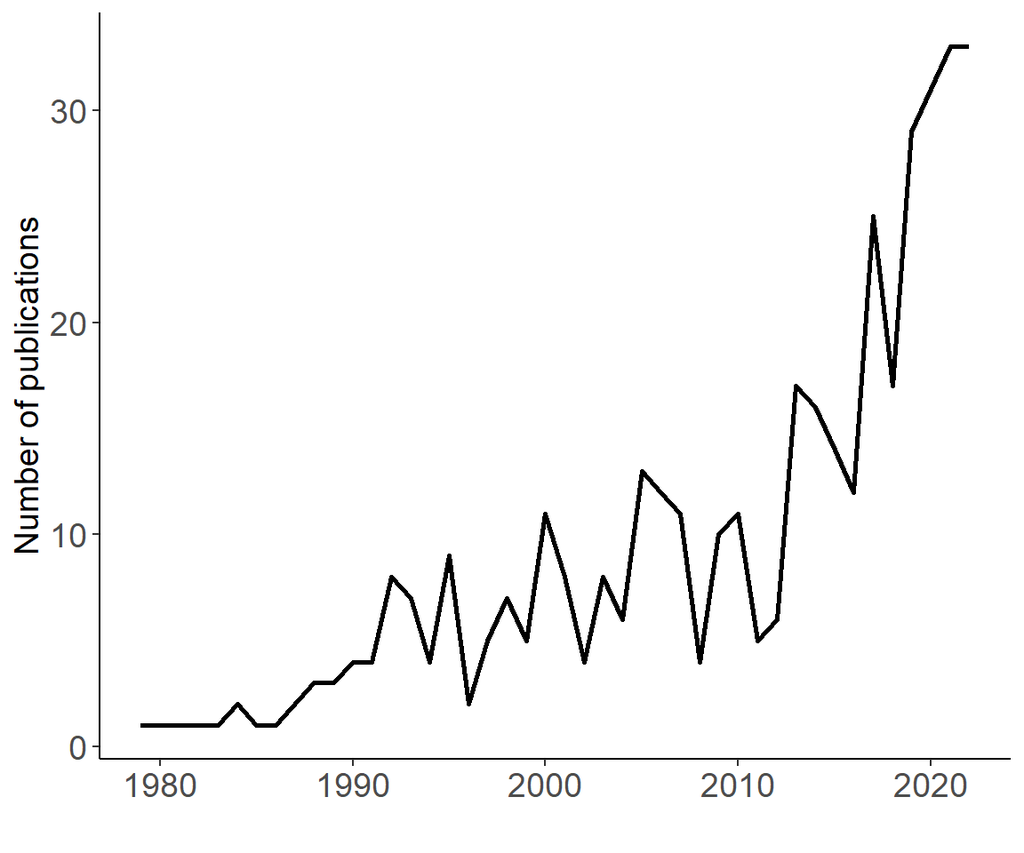

Number of publications per year

## Most common journals

What are the most often-used journals? Note that UNIPED has 10 results, that are not currently included in this analysis due to not being covered by PubMed/WoS. You could also argue that since UNIPED and TNLF were searched in specifically, they could be over-represented.

The ten journals with most publications

| Sources | Articles |
| --- | --- |
| TIDSSKRIFT FOR DEN NORSKE LEGEFORENING | 94 |
| BMC MEDICAL EDUCATION | 45 |
| MEDICAL EDUCATION | 26 |
| MEDICAL TEACHER | 26 |
| PATIENT EDUCATION AND COUNSELING | 10 |
| SURGICAL ENDOSCOPY | 8 |
| SCANDINAVIAN JOURNAL OF PRIMARY HEALTH CARE | 7 |
| JOURNAL OF INTERPROFESSIONAL CARE | 6 |
| ADVANCES IN HEALTH SCIENCES EDUCATION | 4 |
| BMJ OPEN | 4 |

How many are in the top 24 proposed by Maggio?

Publications found in Maggio et al.’s 24 central medical education journals

| SO | Freq | Percentage |
| --- | --- | --- |
| BMC MEDICAL EDUCATION | 45 | 11.1 |
| MEDICAL EDUCATION | 26 | 6.4 |
| MEDICAL TEACHER | 26 | 6.4 |
| ADVANCES IN HEALTH SCIENCES EDUCATION | 4 | 1.0 |
| MEDICAL EDUCATION ONLINE | 4 | 1.0 |
| ADVANCES IN MEDICAL EDUCATION AND PRACTICE | 3 | 0.7 |
| INTERNATIONAL JOURNAL OF MEDICAL EDUCATION | 3 | 0.7 |
| PERSPECTIVES ON MEDICAL EDUCATION | 3 | 0.7 |
| JOURNAL OF SURGICAL EDUCATION | 2 | 0.5 |
| BMJ SIMULATION & TECHNOLOGY ENHANCED LEARNING | 1 | 0.2 |
| EDUCATION FOR HEALTH | 1 | 0.2 |
| GMS JOURNAL FOR MEDICAL EDUCATION | 1 | 0.2 |
| JOURNAL OF CONTINUING EDUCATION IN THE HEALTH PROFESSIONS | 1 | 0.2 |
| JOURNAL OF MEDICAL EDUCATION AND CURRICULAR DEVELOPMENT | 1 | 0.2 |
| TEACHING AND LEARNING IN MEDICINE | 1 | 0.2 |
| Total | 122 | 29.7 |

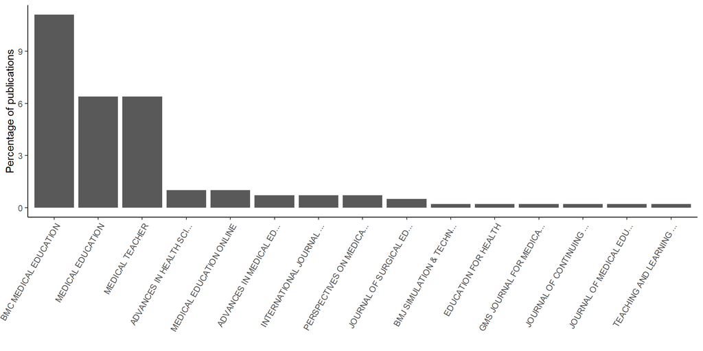

Percentage of publications in Maggio et al.’s central medical education journals

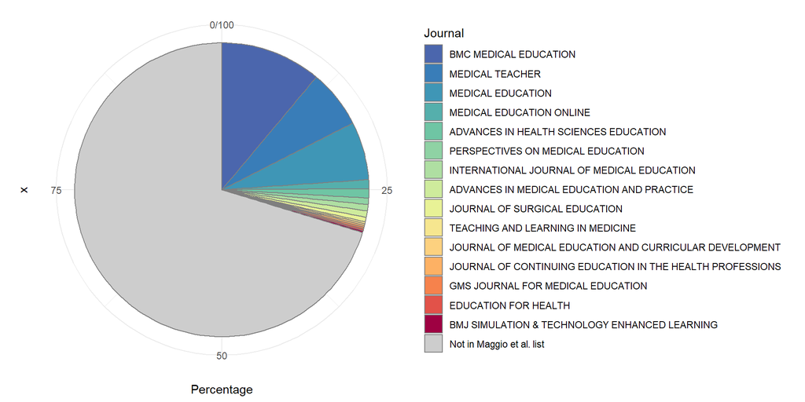

Percentage of publications in Maggio et al.’s central medical education journals

## Institutions

Selected quotes from the documentation of Bibliometrix (https://cran.r-project.org/web/packages/bibliometrix/bibliometrix.pdf):

“The function biblioAnalysis returns an object of class “bibliometrix”. An object of class “bibliometrix” is a list containing the following components: * CO - the affiliation country of the corresponding author * Countries - the affiliation countries’ frequency distribution * FirstAffiliation - the affiliation of the first author * Affiliations - the frequency distribution of affiliations (of all co-authors for each paper)”

### What are the institutions (/sectors) that have published most?

Here we also have to do some cleaning - it seems even the WOS data here under affiliations is not clean, with multiple names for the same institutions. May be because Bibliometrix extracts it directly from the raw affiliations rather than organisation-enhanced. We also have affiliation data from PubMed which is more messy.

I have cleaned those mentioning Norwegian terms and places.

```r
#Make a filter to examine subset of affiliations likely to be in Norway
filterlists<-c("bergen", "haukeland",
              "vestland", "hordaland",
              "oslo", "akershus",
              "trondheim", "tronder", "trønder",
              "ntnu", "norges teknisk", "olav",
              "tromsø", "tromso", "norges arktisk", "nord",
              "stavanger", "haugesund", "kristiansand",
              "rogaland", "sør", "innland", "agder", "buskerud", "ostfold", "oestfold", "vestfold", "levanger",
              "VID", "NORCE", "sintef",
              "sykehus", "sjukehus", "helse", "regional health", "hospital trust", "fhi",
              "norway", "norwegian", "norsk", "lefo", "legeforsk"
              )
```

```r
filteredaff<-dplyr::filter(affiliationsmerge, grepl(paste(filterlists, collapse = "|"), AFF, ignore.case=TRUE))
filteredaff #messy affiliations containing common norwegian places / health trust words
```

```
##                                                                                                             AFF Freq
## 1                                                                                                     UNIV OSLO  122
## 2                                                                                                   UNIV BERGEN   70
## 3                                                                                NORWEGIAN UNIV SCI AND TECHNOL   42
## 4                                                                                            UNIVERSITY OF OSLO   30
## 5                                                                                                OSLO UNIV HOSP   23
## 6                                                                                                   UNIV TROMSO   22
## 7                                                                                                HAUKELAND HOSP   21
## 8                                                                           NORWEGIAN UNIV SCI AND TECHNOL NTNU   21
## 9                                                                                        UIT ARCTIC UNIV NORWAY   18
## 10                                                                                  TRONDHEIM REG AND UNIV HOSP   14
## 11                                                                                          STAVANGER UNIV HOSP   12
## 12                                                                                               UNIV STAVANGER   11
## 13                                                               NORWEGIAN UNIVERSITY OF SCIENCE AND TECHNOLOGY   10
## 14                                                                                     OSLO UNIVERSITY HOSPITAL    9
```

[output cut: 108 more lines]

Note that when cleaning we cannot use truncation because all of the various affiliations are stored in one column, so truncation will replace any other affiliations after the one truncated too.

Table over cleaned affiliations mentioning Norwegian places:

```
##                                                                               AFF Freq
## 1                                                                       UNIV OSLO  173
## 2                                                  NORWEGIAN UNIV SCI AND TECHNOL   91
## 3                                                                     UNIV BERGEN   89
## 4                                                                     UNIV TROMSO   74
## 5                                                      OSLO & AKERSHUS UNIV HOSPS   47
## 6                                                                   ST OLAVS HOSP   38
## 7                                                                  HAUKELAND HOSP   26
## 8                                                       UNIV HOSP NORTHERN NORWAY   18
## 9                                                                  UNIV STAVANGER   14
## 10                                                            STAVANGER UNIV HOSP   12
## 11                                                   WESTERN NORWAY UNIV APPL SCI   12
## 12                                                      UNIV SOUTH EASTERN NORWAY    8
## 13                                                         OSLO METROPOLITAN UNIV    7
## 14                          NORDIC INST STUDIES INNOVATION RESEARCH AND EDUCATION    5
```

[output cut: 28 more lines]

Publications per institution, 15 institutions with most publications

| Affiliation | No. publications |
| --- | --- |
| UNIV OSLO | 173 |
| NORWEGIAN UNIV SCI AND TECHNOL | 91 |
| UNIV BERGEN | 89 |
| UNIV TROMSO | 74 |
| OSLO & AKERSHUS UNIV HOSPS | 47 |
| ST OLAVS HOSP | 38 |
| HAUKELAND HOSP | 26 |
| UNIV HOSP NORTHERN NORWAY | 18 |
| UNIV COPENHAGEN | 16 |
| UNIV STAVANGER | 14 |
| STAVANGER UNIV HOSP | 12 |
| WESTERN NORWAY UNIV APPL SCI | 12 |
| RADBOUD UNIV NIJMEGEN | 11 |
| KAROLINSKA INST | 9 |
| MAASTRICHT UNIV | 9 |

Publications per Norwegian institution, institutions with 5 or more publications

| Affiliation | No. publications | Percentage |
| --- | --- | --- |
| UNIV OSLO | 173 | 56.4 |
| NORWEGIAN UNIV SCI AND TECHNOL | 91 | 29.6 |
| UNIV BERGEN | 89 | 29.0 |
| UNIV TROMSO | 74 | 24.1 |
| OSLO & AKERSHUS UNIV HOSPS | 47 | 15.3 |
| ST OLAVS HOSP | 38 | 12.4 |
| HAUKELAND HOSP | 26 | 8.5 |
| UNIV HOSP NORTHERN NORWAY | 18 | 5.9 |
| UNIV STAVANGER | 14 | 4.6 |
| STAVANGER UNIV HOSP | 12 | 3.9 |
| WESTERN NORWAY UNIV APPL SCI | 12 | 3.9 |
| UNIV SOUTH EASTERN NORWAY | 8 | 2.6 |
| OSLO METROPOLITAN UNIV | 7 | 2.3 |
| NORDIC INST STUDIES INNOVATION RESEARCH AND EDUCATION | 5 | 1.6 |
| VESTFOLD HOSP TRUST | 5 | 1.6 |

```r
#Make a table over time - here for 2020-2022
mergeanalysistime<-(biblioAnalysis(merge_df202022, sep=";"))
affiliationsmergetime <- as.data.frame((mergeanalysistime$Affiliations))
afftabletime<-arrange(affiliationsmergetime, AFF,Freq)
#Top 10
colnames(afftabletime)[which(names(afftabletime) == "AFF")] <- "Affiliation"
colnames(afftabletime)[which(names(afftabletime) == "Freq")] <- "No. publications"
kable(afftabletime, caption="Publications per institution, 10 institutions with most publications per time period")
```

[output not shown]

[output cut: 299 more lines]

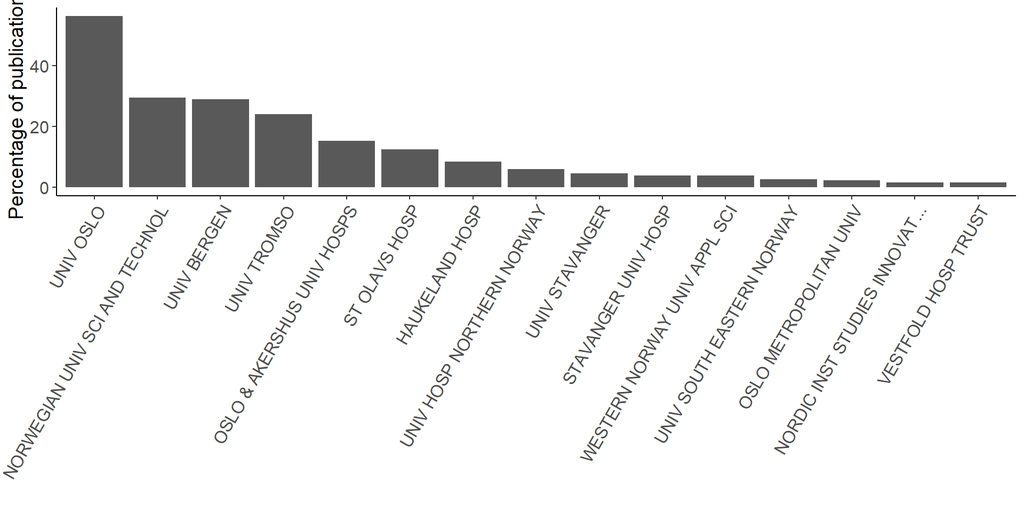

Percentage of publications from each Norwegian institution (>=5 publications)

### Institutional collaboration?

Done using a network analysis tool, VOS viewer (https://www.vosviewer.com/).

## Authors

### Who have published the most publications?

[figure not shown]

### Author collaboration?

Done using a network analysis tool, VOS viewer (https://www.vosviewer.com/).

#### Dominance analysis

| Author | Dominance Factor | Tot Articles | Single-Authored | Multi-Authored | First-Authored | Rank by Articles | Rank by DF |
| --- | --- | --- | --- | --- | --- | --- | --- |
| VAGLUM P | NA | 30 | NA | NA | 1 | 1 | 1 |
| TYSSEN R | NA | 26 | NA | NA | 6 | 2 | 2 |
| BAERHEIM A | NA | 20 | NA | NA | 7 | 3 | 3 |
| GUDE T | NA | 17 | NA | NA | 9 | 4 | 4 |
| HOLEN A | NA | 14 | NA | NA | 1 | 5 | 5 |
| ANVIK T | NA | 12 | NA | NA | 2 | 6 | 6 |
| AASLAND O | NA | 11 | NA | NA | 4 | 7 | 7 |
| SCHEI E | NA | 11 | NA | NA | 4 | 7 | 8 |
| WIERS-JENSSEN J | NA | 10 | NA | NA | 5 | 9 | 9 |
| SCHAUBER S | NA | 8 | NA | NA | 2 | 10 | 10 |
| VAPENSTAD C | NA | 8 | NA | NA | 3 | 10 | 11 |
| FALCK G | NA | 7 | NA | NA | 3 | 12 | 12 |
| DE V M | NA | 6 | NA | NA | 3 | 13 | 13 |
| FRICH J | NA | 6 | NA | NA | 2 | 13 | 14 |
| HEM E | NA | 6 | NA | NA | 1 | 13 | 15 |
| HOFMANN B | NA | 6 | NA | NA | 4 | 13 | 16 |
| HUNSKAAR S | NA | 6 | NA | NA | 4 | 13 | 17 |
| LYCKE K | NA | 6 | NA | NA | 2 | 13 | 18 |
| WESTIN S | NA | 6 | NA | NA | 3 | 13 | 19 |
| ABELSEN B | NA | 5 | NA | NA | 1 | 20 | 20 |

## What are the themes of the research?

Done manually via categorisation of empirical location, type of methods, and educational level.

### What do we see in the keywords?

This is author keywords in WOS, and MeSH terms from PubMed.

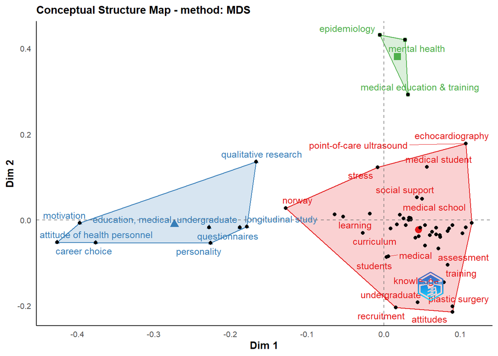

[figure not shown]

## References & guides

https://cran.r-project.org/web/packages/bibliometrix/bibliometrix.pdf

https://www.bibliometrix.org/vignettes/Introduction_to_bibliometrix.html

https://github.com/massimoaria/bibliometrix

Aria, M. & Cuccurullo, C. (2017) bibliometrix: An R-tool for comprehensive science mapping analysis, Journal of Informetrics, 11(4), pp 959-975, Elsevier.

Wickham. ggplot2: Elegant Graphics for Data Analysis. Springer-Verlag New York, 2016.

Wickham et al., (2019). Welcome to the tidyverse. Journal of Open Source Software, 4(43), 1686, https://doi.org/10.21105/joss.01686

Wickham, Romain François, Lionel Henry and Kirill Müller (2021). dplyr: A Grammar of Data Manipulation. R package version 1.0.7. https://CRAN.R-project.org/package=dplyr

Yihui Xie (2021). knitr: A General-Purpose Package for Dynamic Report Generation in R. R package version 1.36.

Yihui Xie (2015) Dynamic Documents with R and knitr. 2nd edition. Chapman and Hall/CRC. ISBN 978-1498716963

Yihui Xie (2014) knitr: A Comprehensive Tool for Reproducible Research in R. In Victoria Stodden, Friedrich Leisch and Roger D. Peng, editors, Implementing Reproducible Computational Research. Chapman and Hall/CRC. ISBN 978-1466561595

JJ Allaire and Yihui Xie and Jonathan McPherson and Javier Luraschi and Kevin Ushey and Aron Atkins and Hadley Wickham and Joe Cheng and Winston Chang and Richard Iannone (2021). rmarkdown: Dynamic Documents for R. R package version 2.11. URL https://rmarkdown.rstudio.com.

Yihui Xie and J.J. Allaire and Garrett Grolemund (2018). R Markdown: The Definitive Guide. Chapman and Hall/CRC. ISBN 9781138359338. URL https://bookdown.org/yihui/rmarkdown.

Yihui Xie and Christophe Dervieux and Emily Riederer (2020). R Markdown Cookbook. Chapman and Hall/CRC. ISBN 9780367563837. URL https://bookdown.org/yihui/rmarkdown-cookbook.